# Взаимоотношения Oithona и Microsetella

Вадим Хайтов

4 марта 2020

Предуведомление. Все анализы, которые я здесь сделал проведены на основе материала по слою воды 0-10 м. Я запутался с тем, как объединить данные по слоям. Возможно, когда слои объединим, то все будет не так… Но пока работаю в этом режиме.

Итак. Базовой посылкой для этого анализа было то, что при изучении фенологии видов мы натолкнулись на зависимость фенологии Oithona от обилия Microsetella. Чем больше обилие микросетеллы, тем позднее происходят некоторые события в жизни оитоны.

Мы видим, что на фоне многолетней тенденции роста обилия микросетеллы идет снижение обилия оитоны, что у нас тоже было в той статье.

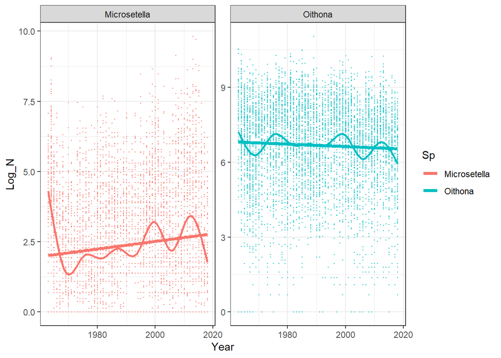

Нечто похожее мы выявили при анализе сезонных процессов в жизни двух видов. На рисунке, приведенном ниже, прослеживается локальное падение обилия оитоны в те периоды, когда наблюдается массовый выход микросетеллы. Кстати, пик микросетеллы очень узкий.

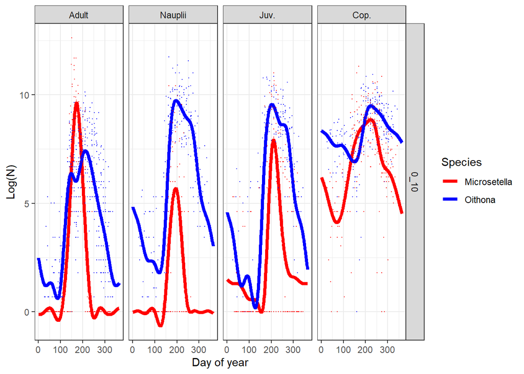

Seasonal dynamics of abundance of different stages. 100 mkm net was used

Это позволяет выдвинуть гипотезу о том, что при высоком обилии микросетеллы они чем-то мешают оитоне (конкуренция и т.п.). Соответственно, следствием этой гипотезы будет то, что обилие оитоны должно как-то коррелировать с обилием микросетеллы. Если это какие-то негативные отношения, то корреляции должны быть отрицательные.

Попытка решить этот вопрос в лоб не привела к чему-то внятному. Вот просто линейная модель, где обилие взрослых оитон рассматривается как функция от обилия разных возрастных стадий микросетелл.

Parameters of model with the model with abundance of Oithona adult as a dependent variable and abundance of different stages of Microsetella as predictors. 200 mkm net was used.

| term | estimate | std.error | statistic | p.value |
| --- | --- | --- | --- | --- |
| (Intercept) | 7.0785662 | 0.3258200 | 21.7253865 | 0.0000000 |
| Adult | -0.0312868 | 0.0714291 | -0.4380119 | 0.6632273 |
| Nauplii | -0.0430628 | 0.0396391 | -1.0863703 | 0.2824234 |
| Juv. | -0.0281545 | 0.0502620 | -0.5601544 | 0.5778265 |
| Cop. | 0.1485798 | 0.1036470 | 1.4335175 | 0.1578126 |

Корреляции, действительно, отрицательные, но не значимые.

Что-то статистически значимое вылезло при анализе зависимости обилия копеподитов.

Parameters of the model with abundance of Oithona Cop. as a dependent variable and abundance of different stages of Microsetella as predictors. 200 mkm net was used.

| term | estimate | std.error | statistic | p.value |
| --- | --- | --- | --- | --- |
| (Intercept) | 6.8558852 | 0.4179915 | 16.4019741 | 0.0000000 |
| Adult | -0.1234915 | 0.0916357 | -1.3476357 | 0.1837320 |
| Nauplii | -0.0205804 | 0.0508527 | -0.4047059 | 0.6873862 |
| Juv. | -0.0644351 | 0.0644806 | -0.9992936 | 0.3223704 |
| Cop. | 0.3152817 | 0.1329678 | 2.3711139 | 0.0215499 |

Но здесь все говорит о положительной связи. То есть обилие копеподитов обоих видов растет синхронно. В этом можно заподозрить роль абиотики, которая однотипно регулирует обилие обоих видов.

Исходя из этого, я предлагаю включить в анализ и абиотку. Данные по абиотическим факторам я взял из того файла, что был использован в предыдущей статье.

Дальше логика такая. Поскольку в популяции оитоны есть несколько стадий, то есть это многомерный объект, то я предлагаю для начала не дробить на много одномерных моделей, что попахивает датамайнингом, а сделать CCA.

В этом анализе зависимой переменной будет матрица обилий стадий оитоны (Cop., Female, Juv., Male, науплиев нет так как 200 мкм сетка). Предикторы следующие: Adult_Mic, Nauplii, Juv., Cop., Adult_1, Cop_1, t_peak, Sp_start, Su_start, Su_end, Ice_clear_G, Su_start_1, Su_duration, Su_duration_1, Su_end_1, t_Spring, t_Summer, t.Spring_1, t_Summer_1, NAO, NAO_1, AOI_DJFM, AOI_1. То, что имеет в названии "_1" это значение предиктора в прошлом году.

Вот что получилось после процедуры подбора оптимальной модели.

Significance of the whole CCA model

| Term | df | Chi Square | F | p.value |
| --- | --- | --- | --- | --- |
| Model | 6 | 0.0434047 | 5.76149 | 3e-05 |
| Residual | 49 | 0.0615243 | NA | NA |

Significance of constrained axis

| Term | df | Chi Square | F | p.value |
| --- | --- | --- | --- | --- |
| CCA1 | 1 | 0.0386070 | 32.6304362 | 0.0001 |
| CCA2 | 1 | 0.0044904 | 3.7952213 | 0.4256 |
| CCA3 | 1 | 0.0003073 | 0.2597507 | 1.0000 |
| Residual | 52 | 0.0615243 | NA | NA |

Significance of particular terms

| Term | df | Chi Square | F | p.value |
| --- | --- | --- | --- | --- |
| Adult_Mic | 1 | 0.0062375 | 4.967765 | 0.0168 |
| Nauplii | 1 | 0.0081914 | 6.523940 | 0.0023 |
| Cop. | 1 | 0.0067611 | 5.384781 | 0.0088 |
| Sp_start | 1 | 0.0142816 | 11.374326 | 0.0008 |
| Ice_clear_G | 1 | 0.0034690 | 2.762822 | 0.0692 |
| AOI_DJFM | 1 | 0.0132683 | 10.567304 | 0.0002 |
| Residual | 49 | 0.0615243 | NA | NA |

А вот визуализация полученной модели.

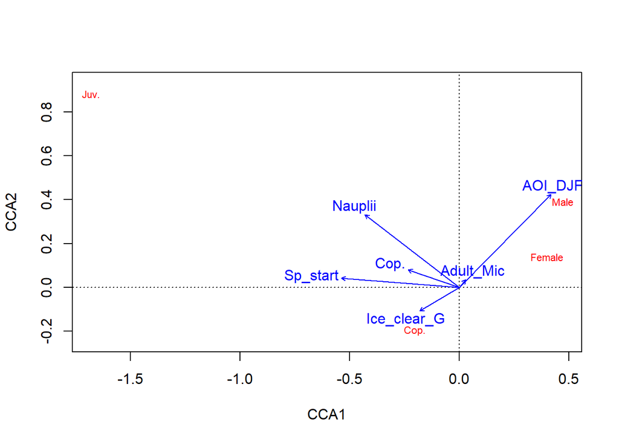

Теперь можно посмотреть как связано обилие взрослых оитон с теми же предикторами, что были использованы в CCA.

После подбора оптимальной модели, результат такой.

Parameters of the model with abundance of adult Oithona as a dependent variable and biotic and abiotic predictors. 200 mkm net was used.

| term | estimate | std.error | statistic | p.value |
| --- | --- | --- | --- | --- |
| (Intercept) | -5421.42324 | 3813.115221 | -1.421783 | 0.1618343 |
| Nauplii | -181.98295 | 63.480764 | -2.866742 | 0.0062365 |
| Cop. | 167.83905 | 100.711333 | 1.666536 | 0.1024027 |
| t_peak | -15.11088 | 7.193070 | -2.100755 | 0.0411724 |
| Sp_start | 45.04414 | 15.327386 | 2.938801 | 0.0051371 |
| Su_end | 20.49413 | 7.130017 | 2.874346 | 0.0061110 |
| Su_start_1 | -15.42207 | 7.399009 | -2.084343 | 0.0427097 |
| t_Spring | 263.61159 | 147.077472 | 1.792331 | 0.0796580 |
| t_Summer | -120.76640 | 71.974876 | -1.677897 | 0.1001500 |
| NAO | 168.60603 | 83.142471 | 2.027917 | 0.0483835 |

Диагностика этой модели небезупречна, но терпима.

Вот, например, автокорреляционная функция для остатков данной модели.

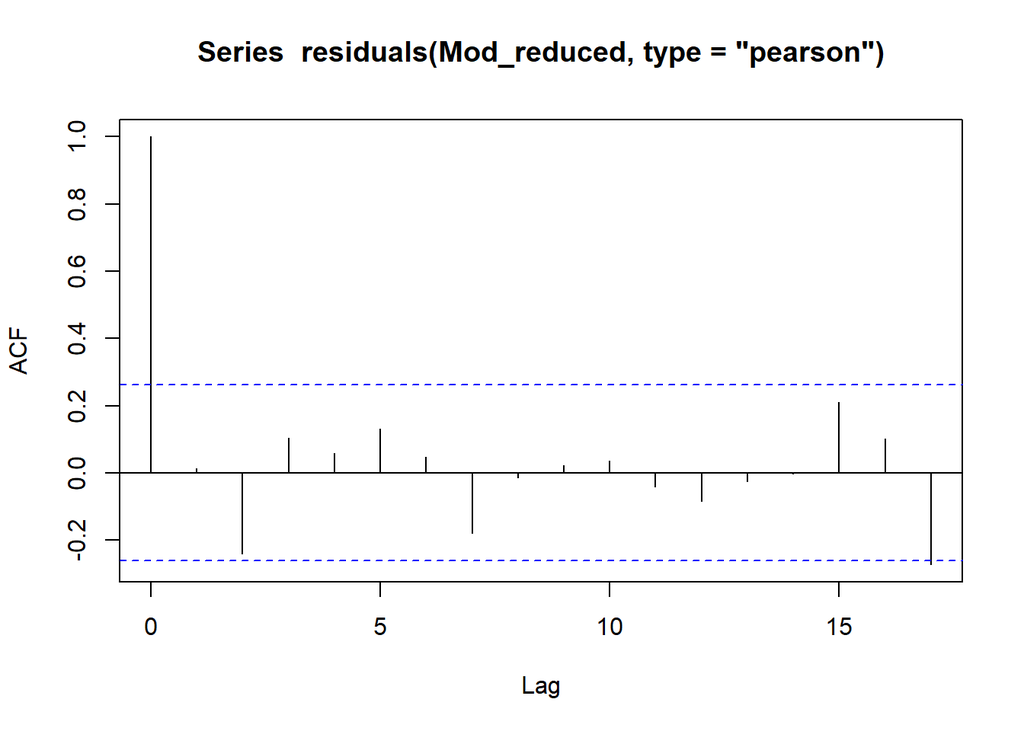

Чуть-чуть сигналит автокорреляция с лагом 2, но формально можно закрыть глаза. На автокорреляции с лагом 17 тем более можно плюнуть.

Стандартный residuls plot у меня тошноты не вызывает. Вроде и гетроскедастичности нет и паттерна заметного тоже не вижу. Можно брать…

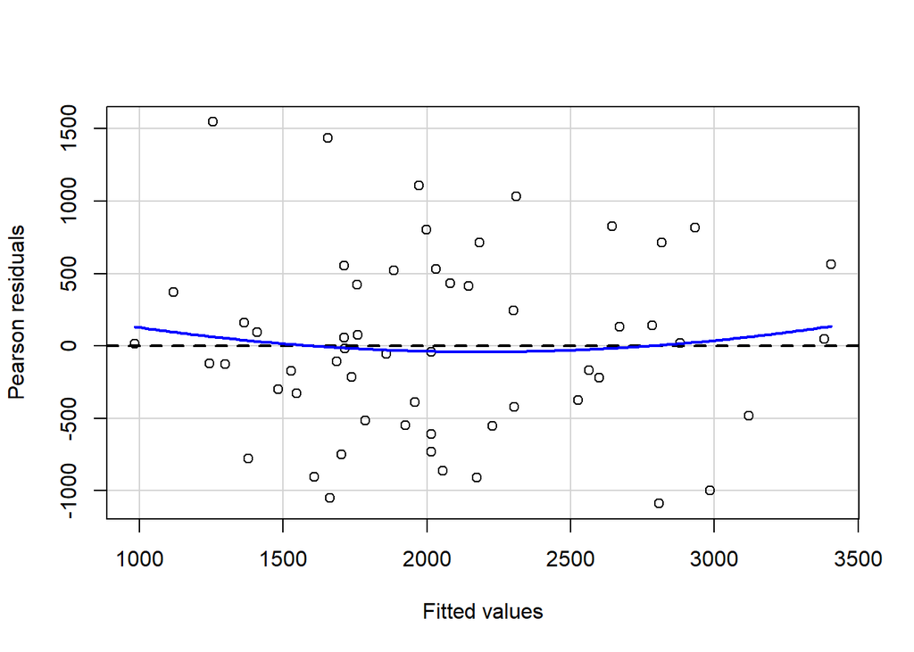

Таким образом, действительно, обилие взрослых оитон отрицательно зависит от обилия науплиусов микросетеллы. НО! при учете всех остальных биотических и абиотических предикторов.

Дальше уже биология…

Но! Надло отдавать себе отчет, что первичные данные очень грубые, а вопрос очень тонкий. Тут без экспериментов не обойтись. Идеально было бы показать какую-то интерверенцию, например, науплиев микросетеллы и взрослых оитон в контролируемом эксперименте. А наболюдаемые корреляции использовать для подтверждения.